# Introduction to the helminthR package

Tad Dallas

2017-10-07

This is an introduction to the `helminthR` package, whicih allows for the programmatic access to the London Natural History Museum’s helminth parasite database ([available here](http://www.nhm.ac.uk/research-curation/scientific-resources/taxonomy-systematics/host-parasites/index.html)). This database represents the largest known database of host-helminth interactions, containing host-helminth occurrence records for over 350 locations, including aquatic, marine, and terrestrial locations.

See software note in *Ecography* ([available here](http://onlinelibrary.wiley.com/doi/10.1111/ecog.02131/full))

### Installation

From GitHub

```r
# install.packages("devtools")
devtools::install_github("rOpenSci/helminthR")
library("helminthR")
```

From CRAN

```r
install.packages("helminthR")
```

## Package functionality

The package allows for the acquisition of host-helminth interaction records based on host name (genus or species), parasite name (genus, species, or group), and/or location (accepted region name as provided by the `listLocations()` function. Parasite groups include “Acanthocephalans”, “Cestodes”, “Monogeans”, “Nematodes”, “Trematodes”, or “Turbs” (short for Turbellarians). The user can further define host species as occuring

1. “In the wild”
2. “Zoo captivity”
3. “Domesticated”
4. “Experimental”
5. “Commercial source”
6. “Accidental infestation”

by inputting the corresponding number above in the `hostState` argument.

The package itself has three main functions; `findHost`, `findParasite`, and `findLocation`.

### Find all helminth parasites of a given host species

Given a host genus and (optionally) species and location, this function returns all host-parasite associations of a given host species. The example below determines all parasite records for helminth infections of *Gorilla gorilla*. We also use the `citation` argument here to obtain information on the citations which the host-helminth occurrences are based on.

```r
library(helminthR)

gorillaParasites <- findHost(genus='Gorilla', species='gorilla',
    hostState=1, speciesOnly=TRUE, citation=TRUE)
dim(gorillaParasites)
```

```
#> [1] 25  5
```

```r
head(gorillaParasites)
```

```
#>                       Host               Parasite
#> 1          Gorilla gorilla              Strongyle
#> 2 Gorilla gorilla beringei              Strongyle
#> 3          Gorilla gorilla     Trichostrongylidae
#> 4          Gorilla gorilla Anoplocephala gorillae
#> 5 Gorilla gorilla beringei Anoplocephala gorillae
#> 6  Gorilla gorilla graueri Anoplocephala gorillae
#>                           ParasiteFull
#> 1                         (Strongyle)
#> 2                         (Strongyle)
#> 3                (Trichostrongylidae)
#> 4 Anoplocephala gorillae Nybelin, 1928
#> 5 Anoplocephala gorillae Nybelin, 1928
#> 6 Anoplocephala gorillae Nybelin, 1928
#>                                                                                                                                                                                                                                                                                                          …
#> 1                                    http://www.nhm.ac.uk/research-curation/scientific-resources/taxonomy-systematics/host-parasites/database/references.jsp;jsessionid=90784895AEF7A32A960164A1B495B89F.web-livecluster1?paragenus=(Strongyle)&paraspecies=&paragroup=&subgroup=&hostgenus=Gorilla&hosts…
#> 2                           http://www.nhm.ac.uk/research-curation/scientific-resources/taxonomy-systematics/host-parasites/database/references.jsp;jsessionid=90784895AEF7A32A960164A1B495B89F.web-livecluster1?paragenus=(Strongyle)&paraspecies=&paragroup=&subgroup=&hostgenus=Gorilla&hostspecies=go…
#> 3                           http://www.nhm.ac.uk/research-curation/scientific-resources/taxonomy-systematics/host-parasites/database/references.jsp;jsessionid=90784895AEF7A32A960164A1B495B89F.web-livecluster1?paragenus=(Trichostrongylidae)&paraspecies=&paragroup=&subgroup=&hostgenus=Gorilla&hosts…
#> 4          http://www.nhm.ac.uk/research-curation/scientific-resources/taxonomy-systematics/host-parasites/database/references.jsp;jsessionid=90784895AEF7A32A960164A1B495B89F.web-livecluster1?paragenus=Anoplocephala&paraspecies=gorillae+Nybelin%2c+1928&paragroup=&subgroup=&hostgenus=Gorilla&hosts…
#> 5 http://www.nhm.ac.uk/research-curation/scientific-resources/taxonomy-systematics/host-parasites/database/references.jsp;jsessionid=90784895AEF7A32A960164A1B495B89F.web-livecluster1?paragenus=Anoplocephala&paraspecies=gorillae+Nybelin%2c+1928&paragroup=&subgroup=&hostgenus=Gorilla&hostspecies=go…
#> 6  http://www.nhm.ac.uk/research-curation/scientific-resources/taxonomy-systematics/host-parasites/database/references.jsp;jsessionid=90784895AEF7A32A960164A1B495B89F.web-livecluster1?paragenus=Anoplocephala&paraspecies=gorillae+Nybelin%2c+1928&paragroup=&subgroup=&hostgenus=Gorilla&hostspecies=g…
#>   CitationNumber
#> 1              1
#> 2              1
#> 3              1
#> 4              1
#> 5              3
#> 6              1
```

```r
hosts <- c('Gorilla gorilla', 'Peromyscus leucopus')
plyr::ldply(hosts,
    function(x){
        findHost(unlist(strsplit(x, ' '))[1],
            unlist(strsplit(x,' '))[2])})
    }
```

### Find all hosts of a given helminth parasite

Given a helminth parasite genus (and optionally species, and location), this function returns a list of host-parasite records for that parasite. In the example below, I query the database for occurrences of the genus *Strongyloides*.

```r
strongHosts <- findParasite(genus='Strongyloides')
dim(strongHosts)
```

```
#> [1] 433   3
```

```r
head(strongHosts)
```

```
#>                       Host                     Parasite
#> 1        Dasyprocta agouti        Strongyloides agoutii
#> 2        Crocidura coerula         Strongyloides akbari
#> 3           Suncus murinus         Strongyloides akbari
#> 4 Peltophryne peltocephala Strongyloides amphibiophilus
#> 5      Nyctanassa violacea         Strongyloides ardeae
#> 6                 (Birds)           Strongyloides avium
#>                                  ParasiteFull
#> 1       Strongyloides agoutii Griffiths, 1940
#> 2  Strongyloides akbari Mirza & Narayan, 1935
#> 3  Strongyloides akbari Mirza & Narayan, 1935
#> 4 Strongyloides amphibiophilus Vigueras, 1942
#> 5           Strongyloides ardeae Little, 1966
#> 6              Strongyloides avium Cram, 1929
```

### `listLocations()` and `findLocation()`

```r
montanaOcc <- findLocation(location='Montana')
dim(montanaOcc)
```

```
#> [1] 97  3
```

```r
head(montanaOcc)
```

```
#>                    Host            Parasite
#> 1        Equus caballus      Cyathostominae
#> 2  Dendragapus obscurus Splendidofilariidae
#> 3        Equus caballus           Strongyle
#> 4         Canis latrans    Alaria marcianae
#> 5 Meriones unguiculatus Brachylaima microti
#> 6    Oreohelix strigosa Brachylaima microti
#>                      ParasiteFull
#> 1               (Cyathostominae)
#> 2          (Splendidofilariidae)
#> 3                    (Strongyle)
#> 4 Alaria marcianae (La Rue, 1917)
#> 5             Brachylaima microti
#> 6             Brachylaima microti
```

### plotting host-helminth networks

Below, I provide an example of plotting the bipartite network of host-helminth interactions found in the state of Montana.

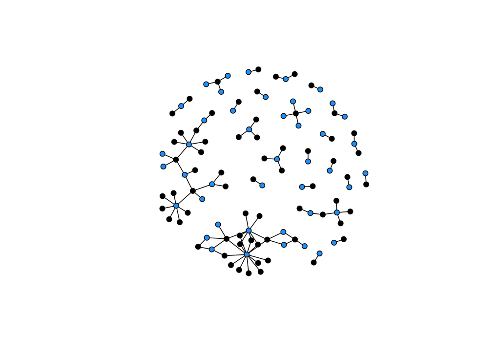

```r
g <- igraph::graph.incidence(table(montanaOcc[,1:2]))
igraph::V(g)$name <- NA
igraph::E(g)$color <- 'black'

plot(g,
    vertex.color=c("black","dodgerblue")[igraph::V(g)$type+1],
    vertex.size=5
)
```